# Laboratory Session 3 – Databases

On this laboratory session, you will be learning how to use databases and why they are very useful for data science or for supplying data for machine learning projects. The session will be divided into two parts:

1. **Relational databases:** you will install PGAdmin and Postgres and learn the basics of seting up a database, querying in SQL, and connecting your database to python to query directly. You will use the [mimic-iii database](https://github.com/MIT-LCP/mimic-code), a critical care database.
2. **Graph databases:** you will be introduced to a different type of databases. This will be done through Neo4j Sandbox. You will not have to install any software, as for this example you will work online. After querying the tool using the Cypher language, you will also try to query your Neo4j database through Python. You will be using the movies database, containing a series of movies, and its actors and directors.

## Databases - MIMIC III

MIMIC-III is a large, freely-available database comprising deidentified health-related data associated with over forty thousand patients (**Note**: in this tutorial just a fraction will be used) who stayed in critical care units of the Beth Israel Deaconess Medical Center between 2001 and 2012. The database includes information such as demographics, vital sign measurements made at the bedside (~1 data point per hour), laboratory test results, procedures, medications, caregiver notes, imaging reports, and mortality (including post-hospital discharge).

MIMIC supports a diverse range of analytic studies spanning epidemiology, clinical decision-rule improvement, and electronic tool development. It is notable for three factors: it is freely available to researchers worldwide; it encompasses a diverse and very large population of ICU patients; and it contains highly granular data, including vital signs, laboratory results, and medications.

### Data description

MIMIC-III is a relational database consisting of 26 tables. Tables are linked by identifiers which usually have the suffix ‘ID’. For example, SUBJECT_ID refers to a unique patient, HADM_ID refers to a unique admission to the hospital, and ICUSTAY_ID refers to a unique admission to an intensive care unit.

Charted events such as notes, laboratory tests, and fluid balance are stored in a series of ‘events’ tables. For example the OUTPUTEVENTS table contains all measurements related to output for a given patient, while the LABEVENTS table contains laboratory test results for a patient.

Tables prefixed with ‘D_’ are dictionary tables and provide definitions for identifiers. For example, every row of CHARTEVENTS is associated with a single ITEMID which represents the concept measured, but it does not contain the actual name of the measurement. By joining CHARTEVENTS and D_ITEMS on ITEMID, it is possible to identify the concept represented by a given ITEMID

Tables composing the database: - admissions: Hospital admissions associated with an ICU stay

- callout: Record of when patients were ready for discharge (called out), and the actual time of their discharge (or more generally, their outcome)
- caregivers: List of caregivers associated with an ICU stay
- chartevents: Events occuring on a patient chart
- cptevents: Events recorded in Current Procedural Terminology
- d_cpt: High-level dictionary of the Current Procedural Terminology
- d_icd_diagnoses: Dictionary of the International Classification of Diseases, 9th Revision (Diagnoses)
- d_icd_procedures: Dictionary of the International Classification of Diseases, 9th Revision (Procedures)
- d_items: Dictionary of non-laboratory-related charted items
- d_labitems: Dictionary of laboratory-related items
- datetimeevents: Events relating to a datetime
- diagnoses_icd: Diagnoses relating to a hospital admission coded using the ICD9 system
- drgcodes: Hospital stays classified using the Diagnosis-Related Group system
- icustays: List of ICU admissions
- inputevents_cv: Events relating to fluid input for patients whose data was originally stored in the CareVue database
- inputevents_mv: Events relating to fluid input for patients whose data was originally stored in the MetaVision database
- labevents: Events relating to laboratory tests
- microbiologyevents: Events relating to microbiology tests
- noteevents: Notes associated with hospital stays
- outputevents: Outputs recorded during the ICU stay
- patients: Patients associated with an admission to the ICU
- procedureevents_mv: Procedure start and stop times recorded for MetaVision patients
- prescriptions: Medicines prescribed
- procedureevents_mv: Procedure start and stop times recorded for MetaVision patients
- procedures_icd: Procedures relating to a hospital admission coded using the ICD9 system
- services: Hospital services that patients were under during their hospital stay
- transfers: Location of patients during their hospital stay

### Create Database

Install [postgresql](https://www.postgresql.org/download/), a open source object-relational database system that has earned it a strong reputation for reliability, feature robustness, and performance.

During installation, confirm that you install `pgAdmin 4` which is a free open source graphical management tool for PostgreSQL and derivative relational databases (as in the figure below)

[figure not shown]

After instalation, follow the steps to create your database:

1. Open `pgAdmin 4’
2. Create your own `username` and `passwourd`
3. Create a new server
   - Right click in Servers -> Create -> Server

[figure not shown]

   - Name your server `mimic`

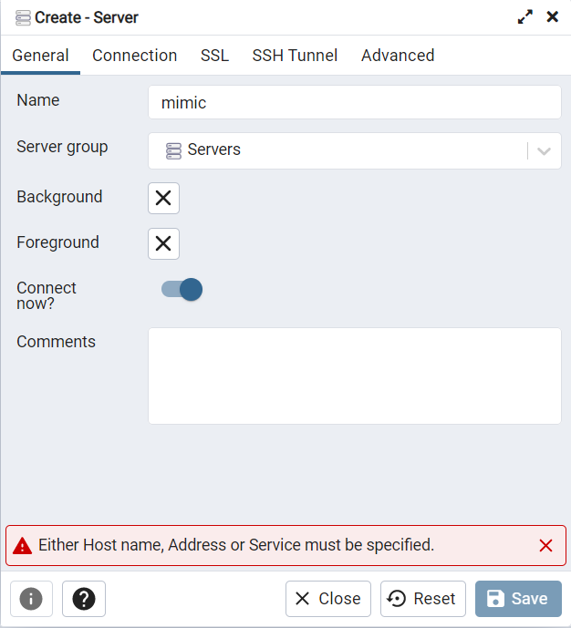

   - In Connection tab insert:
     1. Host name/adress as localhost
     2. Maintenance database as postgres
     3. Previous created credentials (username and password)

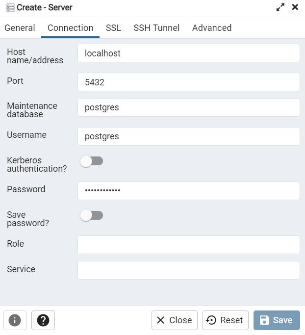

4. Create database
   - Right click on mimic -> Create -> Database

[figure not shown]

   - Name your database `mimic-iii`

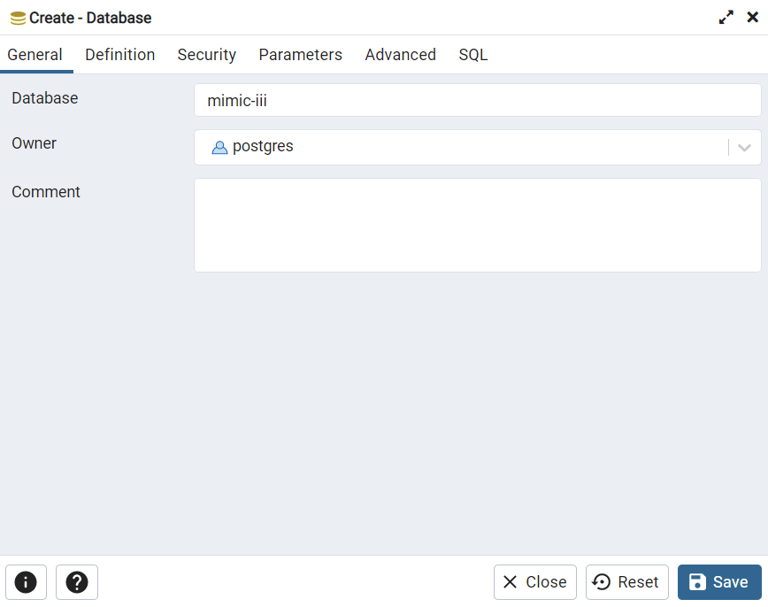

With your server and database created, now it’s time to populate your database. Right click in your database `mimic-iii`and choose `Query Tool`

[figure not shown]

Confirm that you are in the desired server and database in the upper left corner of Query Tool

[figure not shown]

Open and run the .sql files in the following order:

1. Run `postgres_create_tables_mimic.sql` file to generate the MIMIC-III tables

**Important Note**: you should save your .csv files in a folder called data on `C:\data\mimic-iii\` 2. Run `postgres_load_data_mimic.sql` file to populate your database through `.csv` files. 3. Run `postgres_add_indexes_mimic.sql` file to generate tables indexes 4. Run `postgres_add_constraints_mimic.sql` file to generate correspondence between tables

With your database creates, you can now start querying.

### Structured Query Language (SQL)

After loading the data, you will end up with 26 tables, containg large amounts of data. These table can be viewed in Databases > mimic-iii > Schemas > public > Tables.

Start by selecting the table admissions. Right click on it, choose “View/Edit Data” > “First 100 Rows”. A window will open showing the table’s contents. Additionally, on the query editor, a query will be written. This query is the one that returns the data shown:

`SELECT * FROM public.admissions ORDER BY row_id ASC LIMIT 100`

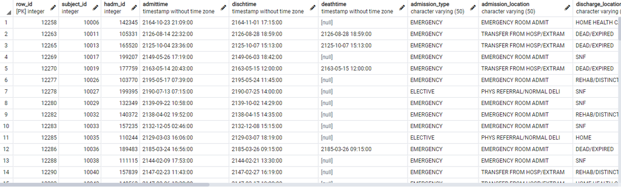

#### Basic Commands

The SQL language is a rather simple programming language, and its basics can be quickly learned. On pgAdmin click on the “Query Tool” button (top left of the editor) to open a new script where yuou can write your own code. Copy and paste the code above and run it (press F5).

The basic syntax of the language uses `SELECT`, then the columns desired (or `*` for all the columns) and then the source. The second row is simply used to order the data and limit the amount displayed.

Try querying only the columns `admission_type` and `diagnosis`, without limiting the search:

`SELECT admission_type, diagnosis FROM public.admissions`

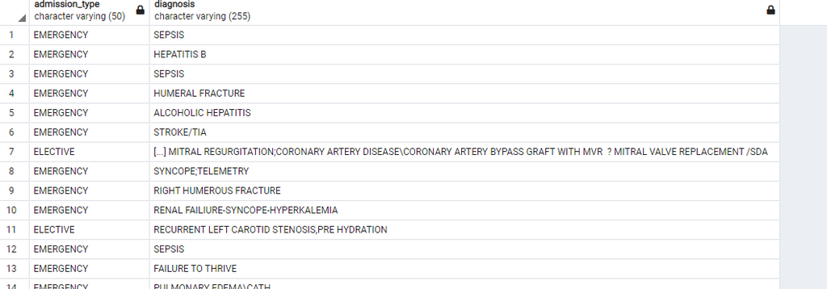

You can count how many rows a table has simply by using the function `COUNT` applied to a columns or to all the columns:

`SELECT COUNT(*) FROM public.admissions`

To create groups, use the group by function. You can order the groups by the count, which is something frequently done.

`SELECT admission_type, COUNT(*) FROM public.admissions`

`GROUP BY admission_type`

`ORDER BY COUNT(*) DESC`

#### Filtering the datasets

Filtering the tables is perhaps one of the most important operations done on tables. To do so, use the function `WHERE` followed by the condition that you want your dataset to respect.

This can be a simple equality filter:

`SELECT * FROM public.admissions`

`WHERE admission_type = 'ELECTIVE'`

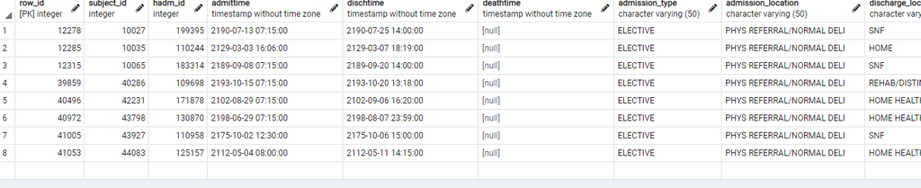

A compound inequality filter:

`SELECT * FROM public.admissions`

`WHERE subject_id > 40000 AND subject_id < 41200`

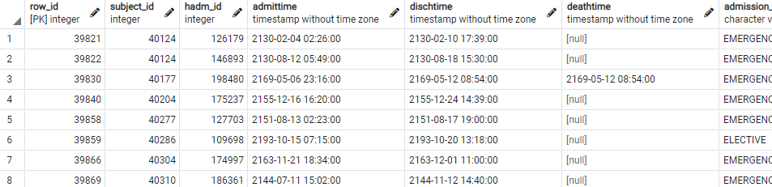

Using ‘OR’ and ‘AND’ operators:

`SELECT * FROM public.admissions`

`WHERE (subject_id > 40000 AND subject_id < 40200) OR admission_type = 'ELECTIVE'`

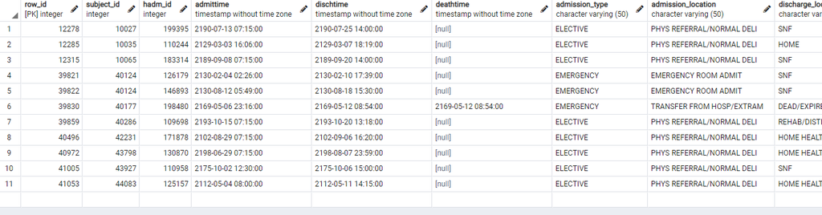

Or using the similarity operator `LIKE` to match approximately the desired string (the % symbols mean anything before and anything after – the diagnosis column must contain the word “CANCER” anywhere):

`SELECT * FROM public.admissions`

`WHERE diagnosis LIKE '%CANCER%'`

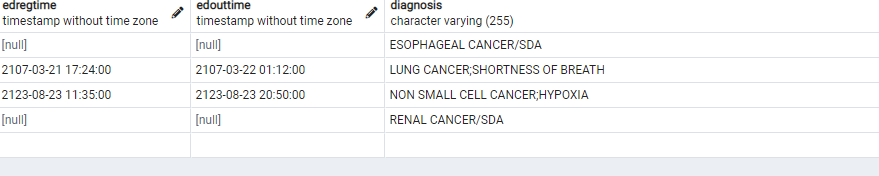

#### Joining Operations

Joining tables is fundamental in SQL. As you can see, there are many table and all of them have unique ids which can be used to connect the tables and join different information. There are 4 types of joins: `LEFT JOIN`, `RIGHT JOIN`, `FULL JOIN` and `INNER JOIN`.

[figure not shown]

The `LEFT JOIN` is the most common type of join used. Imagine yo want to check what prescriptions were made to each admitted pacient. You have the admissions table where each row corresponds to an admission to the ICU (each row has a unique pacient and admission ID – a pacient can be admitted multiple times, but each time the admission ID will be different). On the other side, you have a prescriptions table with multiple rows of data for each admission, meaning that on each admission, several prescriptions are made. You now want to join the tables. This may be done, for example, to obtain correlation between the medicine used (found on the prescriptions table) and the type of insurance, religion, ethnicity or diagnosis (all found on the admissions table).

Since on the admissions table there is a single row per admission, the join will require that row to be multiplied many times, to accomodate each prescription – this is done automatically with the join function. The join works by specifiying which table you want to join, and by which columns you will be joining them:

`SELECT * FROM public.admissions`

`LEFT JOIN public.prescriptions`

`ON public.admissions.subject_id = public.prescriptions.subject_id`

`AND public.admissions.hadm_id = public.prescriptions.hadm_id`

You can now explore the tables and their data freely. There are many operations that can be done and many patterns that may be discovered. You can follow the guides and documentation [here](https://www.postgresqltutorial.com/), but any documentation of PostgreSQL is acceptable. Note that different SQL software have slightly different flavours of SQL. While the basics are the same, there are some small differences. If you plan on using PGAdmin and Postgres, make sure you learn PostgreSQL.

### Python Connection

Install `psycopg2` library to connect python to postgresql allowing query. **Tip**: use the environment previously created to pratical classes

Write the following code to access to database. **Note**: change `user` and `password` to your credentials

```python
import pandas as pd
import numpy as np
import psycopg2 as psql
import matplotlib.pyplot as plt

conn = psql.connect(host='localhost',
                    database='mimic-iii',
                    user='your_username',
                    password='your_password',
                    port=5432)

#Create a cursor object using the cursor() method
cursor = conn.cursor()

#Execute a SQL function using the execute() method
cursor.execute("select version()")

# Fetch a single row using fetchone() method
data = cursor.fetchone()
print("Connection established to: ", data)
```

```
Connection established to:  ('PostgreSQL 14.1, compiled by Visual C++ build 1914, 64-bit',)
```

With the connection established, you can query the databases. Try to get the data from the join example from the previous section into python, to do some data analytics.

```python
# Fetch all rows using fetchall() method
query = "SELECT * FROM public.admissions " +\
        "LEFT JOIN public.prescriptions " +\
        "ON public.admissions.subject_id = public.prescriptions.subject_id " +\
        "AND public.admissions.hadm_id = public.prescriptions.hadm_id"

cursor.execute(query)
```

If at any point you get and error you can run the following code to rollback. Otherwise you have to close and reopen the connection.

```python
#cursor.execute("ROLLBACK")
#conn.commit()
```

The code below obtains the data from the cursor, and also extracts the column names of the extracted data. The data is then convert to pandas dataframe.

```python
colnames = [desc[0] for desc in cursor.description]
data = cursor.fetchall()

#Closing the connection
conn.close()

admission_table = pd.DataFrame(data, columns = colnames)
admission_table
```

|  | row_id | subject_id | hadm_id | admittime | dischtime | deathtime | admission_type | admission_location | discharge_location | insurance | … | drug_name_generic | formulary_drug_cd | gsn | ndc | prod_strength | dose_val_rx | dose_unit_rx | form_val_disp | form_unit_disp | route |
| --- | --- | --- | --- | --- | --- | --- | --- | --- | --- | --- | --- | --- | --- | --- | --- | --- | --- | --- | --- | --- | --- |
| 0 | 40565 | 42458 | 159647 | 2146-07-21 14:45:00 | 2146-07-22 14:45:00 | NaT | EMERGENCY | EMERGENCY ROOM ADMIT | HOME | Medicare | … | PNEUMOcoccal Vac Polyvalent | PNEU25I | 048548 | 00006494300 | 25mcg/0.5mL Vial | 0.5 | mL | 1 | VIAL | IM |
| 1 | 40565 | 42458 | 159647 | 2146-07-21 14:45:00 | 2146-07-22 14:45:00 | NaT | EMERGENCY | EMERGENCY ROOM ADMIT | HOME | Medicare | … | Bisacodyl | BISA5 | 002947 | 00536338101 | 5 mg Tab | 10 | mg | 2 | TAB | PO |
| 2 | 40565 | 42458 | 159647 | 2146-07-21 14:45:00 | 2146-07-22 14:45:00 | NaT | EMERGENCY | EMERGENCY ROOM ADMIT | HOME | Medicare | … | Bisacodyl (Rectal) | BISA10R | 002944 | 00574705050 | 10mg Suppository | 10 | mg | 1 | SUPP | PR |
| 3 | 40565 | 42458 | 159647 | 2146-07-21 14:45:00 | 2146-07-22 14:45:00 | NaT | EMERGENCY | EMERGENCY ROOM ADMIT | HOME | Medicare | … | Senna | SENN187 | 019964 | 00904516561 | 1 Tablet | 1 | TAB | 1 | TAB | PO |
| 4 | 40565 | 42458 | 159647 | 2146-07-21 14:45:00 | 2146-07-22 14:45:00 | NaT | EMERGENCY | EMERGENCY ROOM ADMIT | HOME | Medicare | … | Docusate Sodium (Liquid) | DOCU100L | 003017 | 00121054410 | 100mg UD Cup | 100 | mg | 1 | UDCUP | PO |
| … | … | … | … | … | … | … | … | … | … | … | … | … | … | … | … | … | … | … | … | … | … |
| 10400 | 12385 | 10130 | 156668 | 2161-01-30 16:26:00 | 2161-02-19 14:05:00 | NaT | EMERGENCY | EMERGENCY ROOM ADMIT | HOME HEALTH CARE | Private | … | None | None | None | None | None | None | None | None | None | None |
| 10401 | 12319 | 10069 | 146672 | 2188-02-08 11:15:00 | 2188-02-27 18:41:00 | 2188-02-27 18:41:00 | EMERGENCY | EMERGENCY ROOM ADMIT | DEAD/EXPIRED | Medicaid | … | None | None | None | None | None | None | None | None | None | None |
| 10402 | 12368 | 10117 | 187023 | 2138-06-05 17:23:00 | 2138-06-11 10:16:00 | NaT | EMERGENCY | EMERGENCY ROOM ADMIT | HOME | Private | … | None | None | None | None | None | None | None | None | None | None |
| 10403 | 12317 | 10067 | 160442 | 2130-10-06 01:34:00 | 2130-10-06 02:29:00 | 2130-10-06 02:29:00 | EMERGENCY | EMERGENCY ROOM ADMIT | DEAD/EXPIRED | Private | … | None | None | None | None | None | None | None | None | None | None |
| 10404 | 12365 | 10114 | 167957 | 2171-10-30 19:03:00 | 2171-11-06 14:59:00 | NaT | URGENT | TRANSFER FROM HOSP/EXTRAM | HOME HEALTH CARE | Private | … | None | None | None | None | None | None | None | None | None | None |

10405 rows × 38 columns

As you can see, some rows do not have values for the prescriptions part. These are simply admissions which did not have associated prescriptions. We will now filter these rows out, and remove the unnecessary columns.

```python
keep_cols = ['subject_id', 'hadm_id', 'admittime', 'dischtime','deathtime', 'admission_type',\
             'insurance','language', 'religion','marital_status', 'ethnicity', 'diagnosis',\
             'drug', 'dose_val_rx', 'dose_unit_rx']
admission_table_filtered = admission_table[~admission_table['gsn'].isnull()].copy()
admission_table_filtered = admission_table_filtered[keep_cols]

## Remove duplicated subject_id and hadm_id
admission_table_filtered = admission_table_filtered.iloc[:,list(set(range(
    admission_table_filtered.shape[1]
)) - set([1, 3]))]
admission_table_filtered
```

|  | subject_id | hadm_id | admittime | dischtime | deathtime | admission_type | insurance | language | religion | marital_status | ethnicity | diagnosis | drug | dose_val_rx | dose_unit_rx |
| --- | --- | --- | --- | --- | --- | --- | --- | --- | --- | --- | --- | --- | --- | --- | --- |
| 0 | 42458 | 159647 | 2146-07-21 14:45:00 | 2146-07-22 14:45:00 | NaT | EMERGENCY | Medicare | ENGL | JEWISH | MARRIED | WHITE | PNEUMONIA | Pneumococcal Vac Polyvalent | 0.5 | mL |
| 1 | 42458 | 159647 | 2146-07-21 14:45:00 | 2146-07-22 14:45:00 | NaT | EMERGENCY | Medicare | ENGL | JEWISH | MARRIED | WHITE | PNEUMONIA | Bisacodyl | 10 | mg |
| 2 | 42458 | 159647 | 2146-07-21 14:45:00 | 2146-07-22 14:45:00 | NaT | EMERGENCY | Medicare | ENGL | JEWISH | MARRIED | WHITE | PNEUMONIA | Bisacodyl | 10 | mg |
| 3 | 42458 | 159647 | 2146-07-21 14:45:00 | 2146-07-22 14:45:00 | NaT | EMERGENCY | Medicare | ENGL | JEWISH | MARRIED | WHITE | PNEUMONIA | Senna | 1 | TAB |
| 4 | 42458 | 159647 | 2146-07-21 14:45:00 | 2146-07-22 14:45:00 | NaT | EMERGENCY | Medicare | ENGL | JEWISH | MARRIED | WHITE | PNEUMONIA | Docusate Sodium (Liquid) | 100 | mg |
| … | … | … | … | … | … | … | … | … | … | … | … | … | … | … | … |
| 10390 | 42430 | 100969 | 2142-11-26 21:20:00 | 2142-11-30 10:55:00 | 2142-11-30 10:55:00 | EMERGENCY | Medicare | ENGL | CHRISTIAN SCIENTIST | None | WHITE | CEREBROVASCULAR ACCIDENT | Insulin | 0 | UNIT |
| 10391 | 42430 | 100969 | 2142-11-26 21:20:00 | 2142-11-30 10:55:00 | 2142-11-30 10:55:00 | EMERGENCY | Medicare | ENGL | CHRISTIAN SCIENTIST | None | WHITE | CEREBROVASCULAR ACCIDENT | Lorazepam | 2-4 | mg |
| 10392 | 42430 | 100969 | 2142-11-26 21:20:00 | 2142-11-30 10:55:00 | 2142-11-30 10:55:00 | EMERGENCY | Medicare | ENGL | CHRISTIAN SCIENTIST | None | WHITE | CEREBROVASCULAR ACCIDENT | Pneumococcal Vac Polyvalent | 0.5 | mL |
| 10394 | 42430 | 100969 | 2142-11-26 21:20:00 | 2142-11-30 10:55:00 | 2142-11-30 10:55:00 | EMERGENCY | Medicare | ENGL | CHRISTIAN SCIENTIST | None | WHITE | CEREBROVASCULAR ACCIDENT | Acetaminophen | 650 | mg |
| 10395 | 42430 | 100969 | 2142-11-26 21:20:00 | 2142-11-30 10:55:00 | 2142-11-30 10:55:00 | EMERGENCY | Medicare | ENGL | CHRISTIAN SCIENTIST | None | WHITE | CEREBROVASCULAR ACCIDENT | 0.9% Sodium Chloride | 1000 | mL |

9122 rows × 15 columns

With this dataset, you can try to check what are the most correlated drugs, meaning which drugs are most often prescribed together on a single hospital admission.

```python
from scipy.stats import pearsonr

## Start by assigning the value 1 to the quantity -- we want the number of times the medicine
## was used and not the amount used.
df = admission_table_filtered.copy()
df['dose_val_rx'] = 1

## Concatenated the drug name and unit, to reduce the number of variables to keep
df['drug'] = df['drug'] + ' ' + df['dose_unit_rx']

## Subset the dataframe into just the admission id, drug and quantity
cols = ['hadm_id', 'drug', 'dose_val_rx']
df = df[cols]

## Filter the results by only considering drugs used in total more than 12 times
qtts = df.groupby(['drug'])['dose_val_rx'].count().reset_index()
qtts = qtts['drug'][qtts['dose_val_rx'] > 12]

## Filter out the rows not containing the drugs in study
df = df[df['drug'].isin(qtts)]

## Count the number of drug usage, per admission and type of drug
df = df.groupby(['hadm_id','drug'])['dose_val_rx'].sum().reset_index()

## Pivot the drugs to columns, in order to obtain a matrix with one row per admission and with
## all drugs as columns. Numbers correspond to the times each drug was used on the admission.
## Convert NA values to 0.
df = df.pivot(index = 'hadm_id', columns = 'drug', values = 'dose_val_rx').reset_index()
df = df.fillna(0).drop(columns = 'hadm_id')

## Calculate the correlation matrix. Melt the matrix into a 3 column matrix: drug1, drug2 and the
## correlation between them.
corrs = df.copy().corr()
corrs['drug1'] = corrs.columns
corrs = corrs.melt(id_vars = 'drug1').rename(columns={"value": "corr", 'drug': 'drug2'})

## Do the same for the p-value
pvals = df.copy().corr(method = lambda x,y: pearsonr(x,y)[1])
pvals['drug1'] = pvals.columns
pvals = pvals.melt(id_vars = 'drug1').rename(columns={"value": "pvalue", 'drug': 'drug2'})

## Merge the dataframes, on the drug1 and drug2
final_df = corrs.merge(pvals, on=['drug1', 'drug2'], how='left')

## Considering a statistical significance of 0.1%, filter out
## statistically insignificant correlations.
stat_sig = 0.1/100
final_df_filter = final_df.copy()
final_df_filter = final_df_filter[final_df_filter['pvalue'] < stat_sig]
final_df_filter = final_df_filter[final_df_filter['pvalue'] != 0]

## Print the strongest correlations
final_df_filter.sort_values(by=['corr'], ascending = False).head(25)
```

|  | drug1 | drug2 | corr | pvalue |
| --- | --- | --- | --- | --- |
| 17159 | Calcium Gluconate mEq | Sterile Water ml | 0.978858 | 1.458538e-84 |
| 3254 | Sterile Water ml | Calcium Gluconate mEq | 0.978858 | 1.458538e-84 |
| 10525 | Fosphenytoin mg PE | LeVETiracetam mg | 0.961353 | 4.556935e-69 |
| 7285 | LeVETiracetam mg | Fosphenytoin mg PE | 0.961353 | 4.556935e-69 |
| 17460 | FoLIC Acid mg | Thiamine mg | 0.955444 | 1.951012e-65 |
| 7200 | Thiamine mg | FoLIC Acid mg | 0.955444 | 1.951012e-65 |
| 11663 | Ondansetron mg | Methadone mg | 0.935884 | 3.316303e-56 |
| 14093 | Methadone mg | Ondansetron mg | 0.935884 | 3.316303e-56 |
| 13363 | D5W mL | NS mL | 0.915472 | 2.856457e-49 |
| 4858 | NS mL | D5W mL | 0.915472 | 2.856457e-49 |
| 16269 | Methadone mg | Prochlorperazine mg | 0.911638 | 3.641150e-48 |
| 11679 | Prochlorperazine mg | Methadone mg | 0.911638 | 3.641150e-48 |
| 1258 | D5W (EXCEL BAG) ml | Amiodarone HCl mg | 0.907907 | 3.887627e-47 |
| 4633 | Amiodarone HCl mg | D5W (EXCEL BAG) ml | 0.907907 | 3.887627e-47 |
| 3255 | Tacrolimus mg | Calcium Gluconate mEq | 0.904743 | 2.679344e-46 |
| 17295 | Calcium Gluconate mEq | Tacrolimus mg | 0.904743 | 2.679344e-46 |
| 7243 | D5W mL | Fosphenytoin mg PE | 0.870647 | 8.842128e-39 |
| 4813 | Fosphenytoin mg PE | D5W mL | 0.870647 | 8.842128e-39 |
| 139 | 5% Dextrose mL | 0.9% Sodium Chloride mL | 0.866695 | 4.759564e-38 |
| 409 | 0.9% Sodium Chloride mL | 5% Dextrose mL | 0.866695 | 4.759564e-38 |
| 16287 | Ondansetron mg | Prochlorperazine mg | 0.850046 | 3.304417e-35 |
| 14127 | Prochlorperazine mg | Ondansetron mg | 0.850046 | 3.304417e-35 |
| 17373 | Nitroglycerin mg | Tacrolimus mg | 0.843768 | 3.180092e-34 |
| 13863 | Tacrolimus mg | Nitroglycerin mg | 0.843768 | 3.180092e-34 |
| 12666 | Baclofen mg | Mirtazapine mg | 0.834689 | 7.083770e-33 |

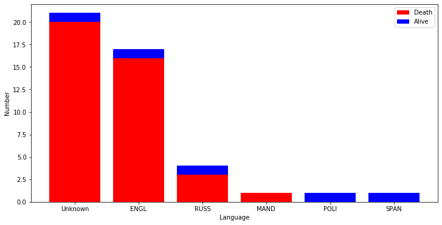

png

```python
deathtimes = admission_table[['deathtime', 'language']]
deathtimes = deathtimes.drop_duplicates()
deathtimes['death'] = ~deathtimes['deathtime'].isna()
deathtimes = deathtimes.drop(columns = 'deathtime')
deathtimes.loc[deathtimes['language'].isna(), 'language'] = 'Unknown'
deathtimes = deathtimes.groupby(['language', 'death']).size().reset_index(name='counts').sort_values(
    by = 'counts'
)


deaths = deathtimes.copy()
deaths.loc[~deaths.death, 'counts'] = 0
deaths = deaths.groupby(['language'])['counts'].sum().reset_index().sort_values(
    by=['counts'], ascending = False
)

alives = deathtimes.copy()
alives.loc[alives.death, 'counts'] = 0
alives = alives.groupby(['language'])['counts'].sum().reset_index()
alives = alives.merge(deaths.rename(columns={"counts": "counts2"}), on=['language'], how='left')
alives = alives.sort_values(by=['counts2'], ascending = False).drop(columns = 'counts2')

## Plot the results
plt.figure(figsize=(12, 6))
plt.bar(deaths.language, deaths.counts, color='r', label = 'Death')
plt.bar(alives.language, alives.counts, bottom=deaths.counts, color='b', label = 'Alive')
plt.legend()
plt.ylim(0, 22)
plt.xlabel("Language")
plt.ylabel("Number")
plt.show()
```

### Dashboard and Visualization

Install [PowerBI](https://powerbi.microsoft.com/pt-pt/downloads/) which is a unified, scalable platform for self-service and enterprise business intelligence (BI) that’s easy to use and helps you gain deeper data insight.

Install [psqlODBC](https://www.postgresql.org/ftp/odbc/versions/msi/) (version in file `psqlodbc_13_02_0000.zip`). Open Database Connectivity (ODBC) is an open standard Application Programming Interface (API) for accessing a database and `psqlODBC`is the extension for Postgresql databases.

Follow the steps to configure the access to your database

1. After installation search in your computer for`ODBC Data Sources` as in figure:

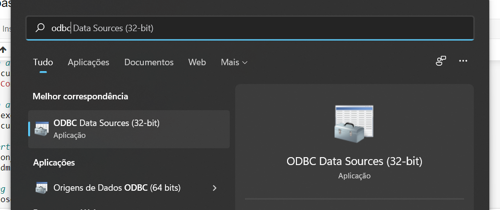

2. Open `ODBC Data Sources` and add a new data origin with PostgreSQL Unicode

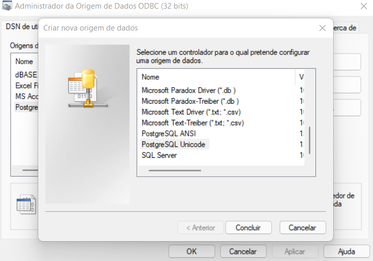

3. Insert your credentials as in the figure:

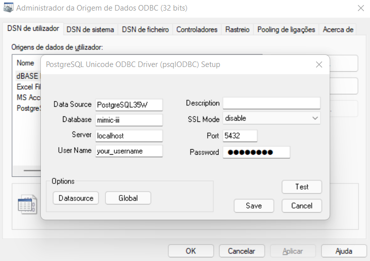

4. Click `Test` in order to verify your connection. If connection unsucessful, re-write your credentials.

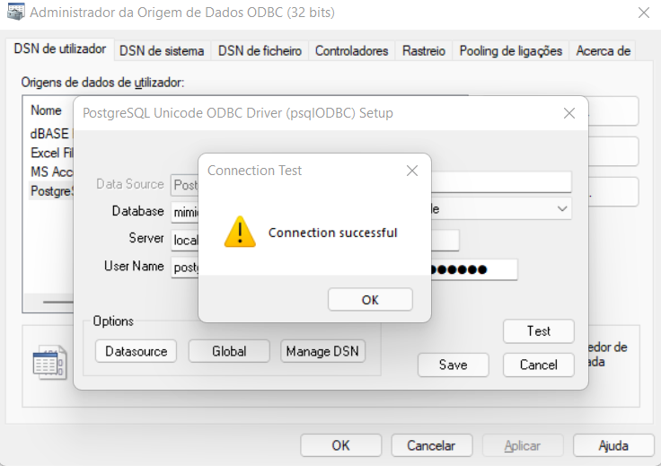

After configuration open `PowerBI` and follow the steps:

1. Access `Get Data/Obter Dados`

[figure not shown]

2. Choose `ODBC` option

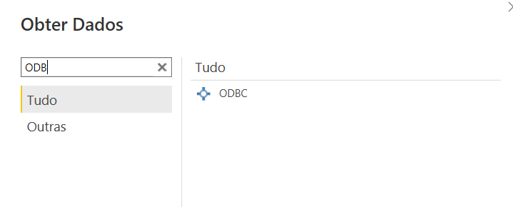

3. Connect to previously created access

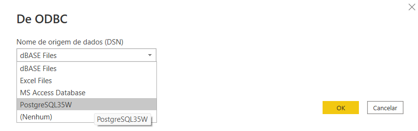

4. Insert your credentials

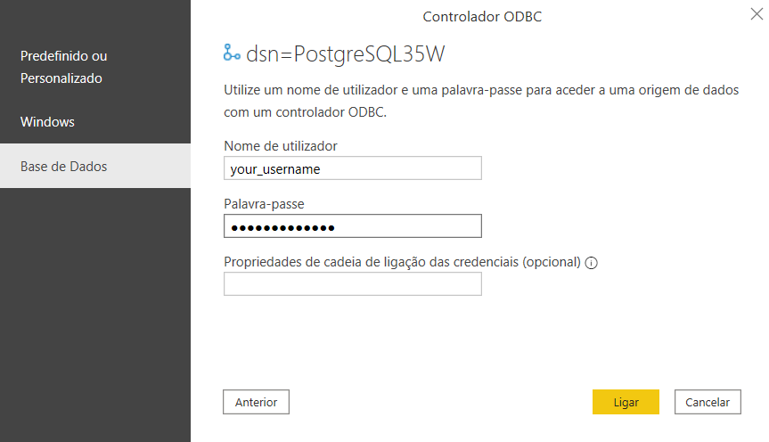

Now, you have access to your database and can choose the necessary tables to visualize data. **Note**: the tables you need to select are indicated in the next chapter.

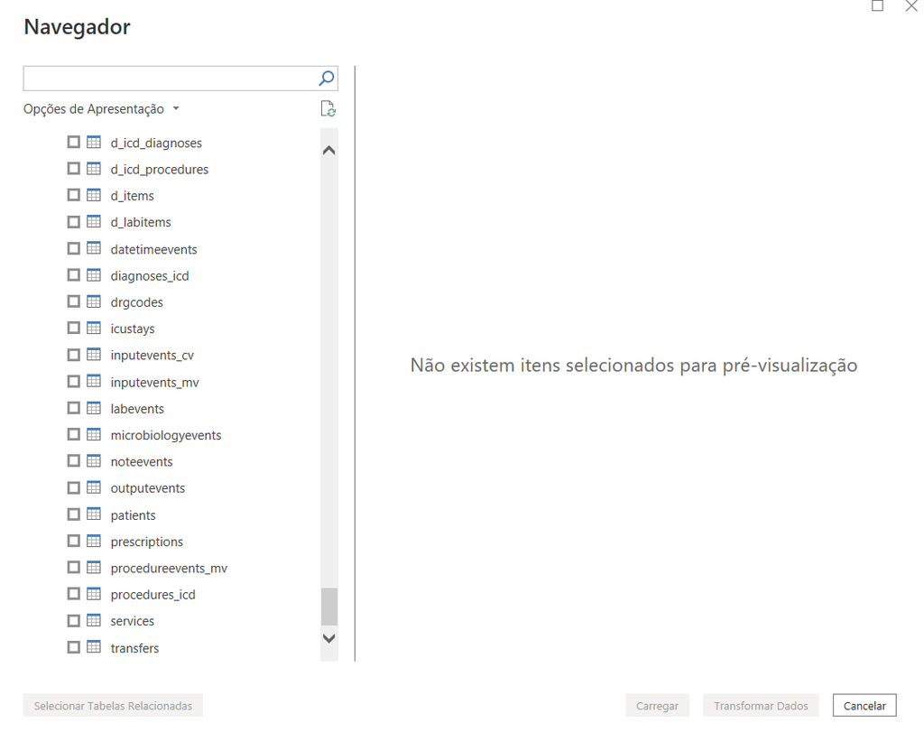

### PowerBI tutorial

The objective of this tutorial is to create a dashboard that shows patients’ information about laboratory measures during their stay in hospital.

An example of the dashboard is presented below and is available to use in files provided:

```python
from IPython.display import IFrame

a='https://app.powerbi.com/reportEmbed?reportId=439ad7ce-73c8-4163-ad0c-162040adb0d5&autoAuth=true&ctid=0bfa8500-b1f2-4566-baf1-6f59370893e7&config=eyJjbHVzdGVyVXJsIjoiaHR0cHM6Ly93YWJpLW5vcnRoLWV1cm9wZS1yZWRpcmVjdC5hbmFseXNpcy53aW5kb3dzLm5ldC8ifQ%3D%3D'
```

```python
IFrame(a,width=1000, height=600)
```

[interactive chart not shown]

#### Step 1 - Select tables

After database connection, select the following tables: - admissions - d_labitems - labevents - patients

#### Step 2 - Create relationships between tables

[figure not shown]

Create the following relations:

- d_labitems and labevents - One to many in `itemid` column
- labevents and admissions - Many to one in `hadm_id` column
- patients and admissions - One to many in `subject_id` column (this one probably will be done already)

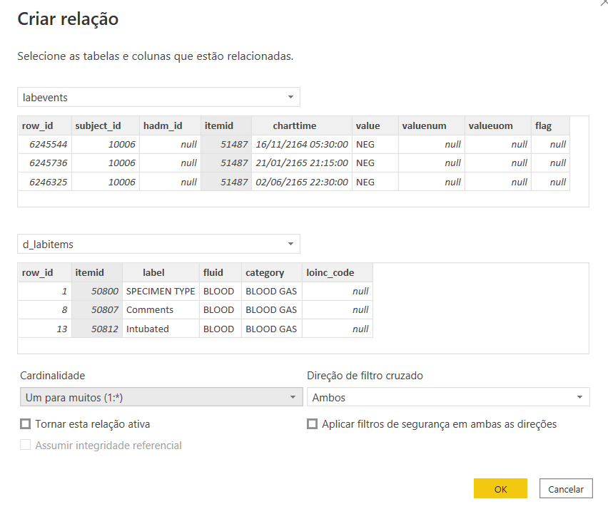

#### Step 3 - Explore and create yout own dashboard

Try to recreate the dashboard above (or similar)

[figure not shown]

Few tips to use power bi:

- In the blue box, you have all the tables and columns. Usually these are represented as `[table].[column]`. To use columns it is only necessary to drag to the workspace and then choose a visualization tool.
- In red, you have the visualization tools necessary to use for the dashboard (you are free to use the tools you desire)
  1. Line Graphs - plot `[labevents].[charttime]` vs `[labevents].[valuenum]` to visualize laboratory measures over time and `[labevents].[itemid]` as legend
  2. Filters - use `[patients].[subject_id]`, `[admissions].[hadm_id]` and `[labevents].[itemid]` to filter the data in all dashboard
  3. Tables - reproduce the tables with the necessary columns
  4. Pie chart - represent information about `[patients].[gender]` and `[admissions].[admission_type]`
- In the green box, you have all the tools to format your graphs (tile,axis,font,…) including some analytical tools (max, min, mean,…)

## Graph Databases

While relational databases are the most common types of storing and accessing data, there are other methods of doing so. Each method has its own advantages and disadvantages, and may be used for different purposes. One of the most common types of databases are the graph databases. Instead of the data being stored on several tables, which follow a schema and can be related via unique indices, graph databases work through nodes and relationships.

One of the most common and easily accessible graph database is the Neo4j. Neo4j is queried using the Cypher language, a different language from SQL, but similar and relatively simple to use.

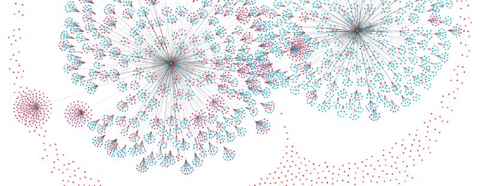

**1.** Access the [Neo4j Sandbox website](https://neo4j.com/sandbox/) and create a free account, by clicking on the “Launch the Free Sandbox” button.

**2.** Click on “New Project”, select the **Movies** dataset and click on “Create”. If you want to learn more about Neo4j and its capabilities, you can try out different datasets. Each of them offer a tutorial and shows what you are able to accomplish with graph databases.

**3.** After creating the project, open it in the browser.

**4.** Follow the “Movies Project Tutorial”. This tutorial shows the basic workings of Neo4j and allows you to grasp its usefulness. If you accidentally close the tutotial, you can reopen it by clicking on “Database” (top of the left panel), and “Show Guide” (bottom of the opened panel).

**5.** After finishing the guide, close it and run the code `:play movies`. This is a slightly more complex guide which can show you additional features of Neo4j. **Do not do step 2 of the guide**

The databases that you create can be accessed externally. You will now be asked to connect your database to python and run a few queries from there. Install the neo4j Python library on your AAut virtual environment. Use the code `pip install neo4j` to do it, since the anaconda distribution does not include the official neo4j library as of now.

**6.** To connect to your Neo4j database, go to your [Neo4j sandbox page](https://sandbox.neo4j.com/) and click on the triangle on the furthest right of your database. A dropdown panel should appear, with a few tabs. Select the “Connection details” tab and copy and paste below the Bolt URL, username and password. **Note that the username and password are not your account username and password; instead, these are the database ones, found in the Connection details tab.**

```python
from neo4j import GraphDatabase
import json
import pandas as pd

uri = "bolt://54.161.214.216:7687"
user = "neo4j"
password = "tendency-glazes-reconfiguration"

driver = GraphDatabase.driver(uri, auth=(user, password))
session = driver.session()
```

**7.** Query all the people’s names from the database.

```python
query = "MATCH (people:Person) RETURN people.name"
result = session.run(query)

json_data = json.dumps(result.data())

data = json.loads(json_data)
df = pd.DataFrame(data)
df
```

|  | people.name |
| --- | --- |
| 0 | Keanu Reeves |
| 1 | Carrie-Anne Moss |
| 2 | Laurence Fishburne |
| 3 | Hugo Weaving |
| 4 | Lilly Wachowski |
| … | … |
| 128 | Penny Marshall |
| 129 | Paul Blythe |
| 130 | Angela Scope |
| 131 | Jessica Thompson |
| 132 | James Thompson |

133 rows × 1 columns

**8.** Obtain all the people related to the movie “Top Gun”, their birth year and the role they played in the movie.

```python
query = 'MATCH (m:Movie {title: "Top Gun"})-[relatedTo]-(p:Person) RETURN p.name, p.born, type(relatedTo), m.title'
result = session.run(query)

json_data = json.dumps(result.data())
data = json.loads(json_data)

df = pd.DataFrame(data)
df
```

|  | p.name | p.born | type(relatedTo) | m.title |
| --- | --- | --- | --- | --- |
| 0 | Jim Cash | 1941 | WROTE | Top Gun |
| 1 | Val Kilmer | 1959 | ACTED_IN | Top Gun |
| 2 | Tony Scott | 1944 | DIRECTED | Top Gun |
| 3 | Meg Ryan | 1961 | ACTED_IN | Top Gun |
| 4 | Tom Skerritt | 1933 | ACTED_IN | Top Gun |
| 5 | Kelly McGillis | 1957 | ACTED_IN | Top Gun |
| 6 | Tom Cruise | 1962 | ACTED_IN | Top Gun |
| 7 | Anthony Edwards | 1962 | ACTED_IN | Top Gun |

**9.** Following the “six degrees of Kevin Bacon” from the tutorial, obtain the degrees of separation of all the other people in relation to Kevin Bacon.

```python
query = "MATCH (KevinB:Person {name: 'Kevin Bacon'}), (Al:Person)," +\
        "p = shortestPath((KevinB)-[*]-(Al))" +\
        "WHERE Al.name <> 'Kevin Bacon'" +\
        "RETURN Al.name AS Actor, length(p)/2 AS Separation"

result = session.run(query)

json_data = json.dumps(result.data())
data = json.loads(json_data)

df = pd.DataFrame(data)
df.sort_values(by=['Separation'])
```

|  | Actor | Separation |
| --- | --- | --- |
| 110 | Michael Sheen | 1 |
| 105 | Sam Rockwell | 1 |
| 106 | Gary Sinise | 1 |
| 109 | Frank Langella | 1 |
| 91 | Ron Howard | 1 |
| … | … | … |
| 99 | Matthew Fox | 3 |
| 98 | Susan Sarandon | 3 |
| 96 | Emile Hirsch | 3 |
| 72 | Orlando Jones | 3 |
| 97 | John Goodman | 3 |

132 rows × 2 columns